# Problemas01

Marina García Lechuga

# Problema 1:

Aplicar todos los criterios de toma de decisiones bajo incertidumbre, en tablas separadas, donde los valores vienen recogidos por la siguiente matriz. Son 6 estados de la naturaleza y 3 situaciones.

```
 e1  e2  e3  e4  e5  e6
```

d1 8 3 5 2 0 0 d2 5 4 10 9 8 1 d3 12 11 3 7 5 1

```r
source("teoriadecision_funciones_incertidumbre.R") #cargamos todas las funciones necesarias para resolver el problema

tabla1 = crea.tablaX(c(8,3,5,2,0,0,
                       5,4,10,9,8,1,
                       12,11,3,7,5,1), numalternativas = 3, numestados = 6)
tabla1
```

```
##    e1 e2 e3 e4 e5 e6
## d1  8  3  5  2  0  0
## d2  5  4 10  9  8  1
## d3 12 11  3  7  5  1
```

## Si la tabla fuera favorable:

### Criterio de Wald

```r
cWaldF = criterio.Wald(tabla1, favorable = T)
cWaldF
```

```
## $criterio
## [1] "Wald"
##
## $metodo
## [1] "favorable"
##
## $tablaX
##    e1 e2 e3 e4 e5 e6
## d1  8  3  5  2  0  0
## d2  5  4 10  9  8  1
## d3 12 11  3  7  5  1
##
## $ValorAlternativas
## d1 d2 d3
##  0  1  1
##
## $ValorOptimo
## [1] 1
##
## $AlternativaOptima
## d2 d3
##  2  3
```

```r
cat("Para el criterio de Wald, las aleternativas óptimas serian", names(cWaldF$AlternativaOptima))
```

```
## Para el criterio de Wald, las aleternativas óptimas serian d2 d3
```

### Criterio Optimista

```r
cOptF = criterio.Optimista(tabla1, favorable = T)
cOptF
```

```
## $criterio
## [1] "Optimista"
##
## $metodo
## [1] "favorable"
##
## $tablaX
##    e1 e2 e3 e4 e5 e6
## d1  8  3  5  2  0  0
## d2  5  4 10  9  8  1
## d3 12 11  3  7  5  1
##
## $ValorAlternativas
## d1 d2 d3
##  8 10 12
##
## $ValorOptimo
## [1] 12
##
## $AlternativaOptima
## d3
##  3
```

```r
cat("Para el criterio optimista, la alernativa óptima sería", names(cOptF$AlternativaOptima))
```

```
## Para el criterio optimista, la alernativa óptima sería d3
```

### Criterio de Hurwicz con alpha = 0.6

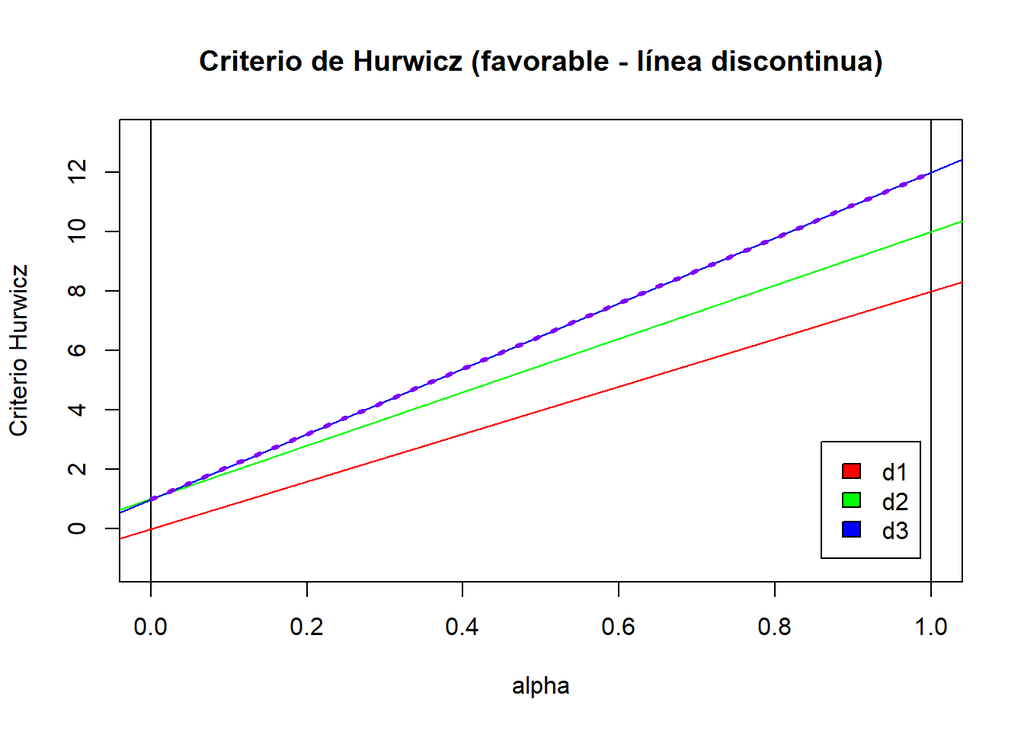

```r
cHurF = criterio.Hurwicz(tabla1, alfa = 0.6, favorable = T)
dibuja.criterio.Hurwicz(tabla1) #Se ve graficamente cual es la decisión tomada
```

```r
cHurF
```

```
## $criterio
## [1] "Hurwicz"
##
## $alfa
## [1] 0.6
##
## $metodo
## [1] "favorable"
##
## $tablaX
##    e1 e2 e3 e4 e5 e6
## d1  8  3  5  2  0  0
## d2  5  4 10  9  8  1
## d3 12 11  3  7  5  1
##
## $ValorAlternativas
##  d1  d2  d3
## 4.8 6.4 7.6
##
## $ValorOptimo
## [1] 7.6
##
## $AlternativaOptima
## d3
##  3
```

```r
cat("Para el criterio de Hurwica, ", names(cHurF$AlternativaOptima), " sería la alternativa óptima")
```

```
## Para el criterio de Hurwica,  d3  sería la alternativa óptima
```

### Criterio de Savage

```r
cSavF = criterio.Savage(tabla1, favorable = T)
cSavF
```

```
## $criterio
## [1] "Savage"
##
## $metodo
## [1] "favorable"
##
## $tablaX
##    e1 e2 e3 e4 e5 e6
## d1  8  3  5  2  0  0
## d2  5  4 10  9  8  1
## d3 12 11  3  7  5  1
##
## $Mejores
## e1 e2 e3 e4 e5 e6
## 12 11 10  9  8  1
##
## $Pesos
##    e1 e2 e3 e4 e5 e6
## d1  4  8  5  7  8  1
## d2  7  7  0  0  0  0
## d3  0  0  7  2  3  0
##
## $ValorAlternativas
## d1 d2 d3
##  8  7  7
##
## $ValorOptimo
## [1] 7
##
## $AlternativaOptima
## d2 d3
##  2  3
```

```r
cat("Para el criterio de Savage, las aleternativas óptimas serian", names(cSavF$AlternativaOptima))
```

```
## Para el criterio de Savage, las aleternativas óptimas serian d2 d3
```

### Criterio de Laplace

```r
cLapF = criterio.Laplace(tabla1, favorable = T)
cLapF
```

```
## $criterio
## [1] "Laplace"
##
## $metodo
## [1] "favorable"
##
## $tablaX
##    e1 e2 e3 e4 e5 e6
## d1  8  3  5  2  0  0
## d2  5  4 10  9  8  1
## d3 12 11  3  7  5  1
##
## $ValorAlternativas
##       d1       d2       d3
## 3.000000 6.166667 6.500000
##
## $ValorOptimo
## [1] 6.5
##
## $AlternativaOptima
## d3
##  3
```

```r
cat(names(cLapF$AlternativaOptima), "es la alternativa óptima según el criterio de Laplace")
```

```
## d3 es la alternativa óptima según el criterio de Laplace
```

### Criterio del punto ideal

```r
cPIF = criterio.PuntoIdeal(tabla1, favorable = T)
cPIF
```

```
## $criterio
## [1] "Punto Ideal"
##
## $metodo
## [1] "favorable"
##
## $tablaX
##    e1 e2 e3 e4 e5 e6
## d1  8  3  5  2  0  0
## d2  5  4 10  9  8  1
## d3 12 11  3  7  5  1
##
## $Mejores
## e1 e2 e3 e4 e5 e6
## 12 11 10  9  8  1
##
## $ValorAlternativas
##        d1        d2        d3
## 14.798649  9.899495  7.874008
##
## $ValorOptimo
## [1] 7.874008
##
## $AlternativaOptima
## d3
##  3
```

```r
cat("La alternativa óptima por el criterio del punto ideal es ", names(cPIF$AlternativaOptima))
```

```
## La alternativa óptima por el criterio del punto ideal es  d3
```

Para esta matriz de datos y siendo favorable la alternativa escogida por todos los criterios ha sido la tercera.

## Si la tabla fuera desfavorable:

### Criterio de Wald

```r
cWaldnF = criterio.Wald(tabla1, favorable = F)
cWaldnF
```

```
## $criterio
## [1] "Wald"
##
## $metodo
## [1] "desfavorable"
##
## $tablaX
##    e1 e2 e3 e4 e5 e6
## d1  8  3  5  2  0  0
## d2  5  4 10  9  8  1
## d3 12 11  3  7  5  1
##
## $ValorAlternativas
## d1 d2 d3
##  8 10 12
##
## $ValorOptimo
## [1] 8
##
## $AlternativaOptima
## d1
##  1
```

```r
cat("Para el criterio de Wald, las aleternativas óptimas serian", names(cWaldnF$AlternativaOptima))
```

```
## Para el criterio de Wald, las aleternativas óptimas serian d1
```

### Criterio Optimista

```r
cOptnF = criterio.Optimista(tabla1, favorable = F)
cOptnF
```

```
## $criterio
## [1] "Optimista"
##
## $metodo
## [1] "desfavorable"
##
## $tablaX
##    e1 e2 e3 e4 e5 e6
## d1  8  3  5  2  0  0
## d2  5  4 10  9  8  1
## d3 12 11  3  7  5  1
##
## $ValorAlternativas
## d1 d2 d3
##  0  1  1
##
## $ValorOptimo
## [1] 0
##
## $AlternativaOptima
## d1
##  1
```

```r
cat("Para el criterio optimista, la alernativa óptima sería", names(cOptnF$AlternativaOptima))
```

```
## Para el criterio optimista, la alernativa óptima sería d1
```

### Criterio de Hurwicz con alpha = 0.6

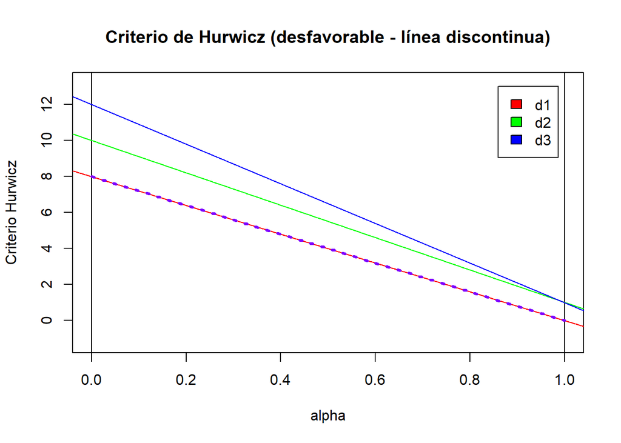

```r
cHurnF = criterio.Hurwicz(tabla1, alfa = 0.6, favorable = F)
dibuja.criterio.Hurwicz(tabla1, favorable = F) #Se ve graficamente cual es la decisión tomada
```

```r
cHurnF
```

```
## $criterio
## [1] "Hurwicz"
##
## $alfa
## [1] 0.6
##
## $metodo
## [1] "desfavorable"
##
## $tablaX
##    e1 e2 e3 e4 e5 e6
## d1  8  3  5  2  0  0
## d2  5  4 10  9  8  1
## d3 12 11  3  7  5  1
##
## $ValorAlternativas
##  d1  d2  d3
## 3.2 4.6 5.4
##
## $ValorOptimo
## [1] 3.2
##
## $AlternativaOptima
## d1
##  1
```

```r
cat("Para el criterio de Hurwica, ", names(cHurnF$AlternativaOptima), " sería la alternativa óptima")
```

```
## Para el criterio de Hurwica,  d1  sería la alternativa óptima
```

### Criterio de Savage

```r
cSavnF = criterio.Savage(tabla1, favorable = F)
cSavnF
```

```
## $criterio
## [1] "Savage"
##
## $metodo
## [1] "desfavorable"
##
## $tablaX
##    e1 e2 e3 e4 e5 e6
## d1  8  3  5  2  0  0
## d2  5  4 10  9  8  1
## d3 12 11  3  7  5  1
##
## $Mejores
## e1 e2 e3 e4 e5 e6
##  5  3  3  2  0  0
##
## $Pesos
##    e1 e2 e3 e4 e5 e6
## d1  3  0  2  0  0  0
## d2  0  1  7  7  8  1
## d3  7  8  0  5  5  1
##
## $ValorAlternativas
## d1 d2 d3
##  3  8  8
##
## $ValorOptimo
## [1] 3
##
## $AlternativaOptima
## d1
##  1
```

```r
cat("Para el criterio de Savage, las aleternativas óptimas serian", names(cSavnF$AlternativaOptima))
```

```
## Para el criterio de Savage, las aleternativas óptimas serian d1
```

### Criterio de Laplace

```r
cLapnF = criterio.Laplace(tabla1, favorable = F)
cLapnF
```

```
## $criterio
## [1] "Laplace"
##
## $metodo
## [1] "desfavorable"
##
## $tablaX
##    e1 e2 e3 e4 e5 e6
## d1  8  3  5  2  0  0
## d2  5  4 10  9  8  1
## d3 12 11  3  7  5  1
##
## $ValorAlternativas
##       d1       d2       d3
## 3.000000 6.166667 6.500000
##
## $ValorOptimo
## [1] 3
##
## $AlternativaOptima
## d1
##  1
```

```r
cat(names(cLapnF$AlternativaOptima), "es la alternativa óptima según el criterio de Laplace")
```

```
## d1 es la alternativa óptima según el criterio de Laplace
```

### Criterio del punto ideal

```r
cPInF = criterio.PuntoIdeal(tabla1, favorable = F)
cPInF
```

```
## $criterio
## [1] "Punto Ideal"
##
## $metodo
## [1] "desfavorable"
##
## $tablaX
##    e1 e2 e3 e4 e5 e6
## d1  8  3  5  2  0  0
## d2  5  4 10  9  8  1
## d3 12 11  3  7  5  1
##
## $Mejores
## e1 e2 e3 e4 e5 e6
##  5  3  3  2  0  0
##
## $ValorAlternativas
##        d1        d2        d3
##  3.605551 12.806248 12.806248
##
## $ValorOptimo
## [1] 3.605551
##
## $AlternativaOptima
## d1
##  1
```

```r
cat("La alternativa óptima por el criterio del punto ideal es ", names(cPInF$AlternativaOptima))
```

```
## La alternativa óptima por el criterio del punto ideal es  d1
```

Para esta matriz de datos y siendo desfavorable, la alternativa escogida por todos los criterios ha sido la primera.

# Problema 2:

Una almazara, cooperativa de aceite, tiene que decidir si abre para la cosecha de ese año o por el contrario la alquila. Esto de’penderá de la posible cosewcha y de los beneficios qie se obtendrán de la venta de aceite. Se sabe que la producción de todos los años ronda las 200 toneladas de aceitunas, por lo tanto los gastos de producción ronda los 15 céntimos por litro. A parte, se tienen unos gastos fijos de 15000€. Si se alquilase la almazara, los gastos fijos habría que pagarlos, sin embargo, los gastos de producción quedarían a cargo del arrendatario.

Si durante el año lleuve y no hace viento, la producción de aceite es de 1 litro por cada kilo de aceitunas y el precio del litro al venderlo es de 1€. Si durante el año lluve bastante y hace viento, la producción de aceite es la misma que en el caso anterior pero el precio de venta aumneta a 1,50€ el litro. Por el contrario, si durante el año no llueve, la producción de aceite disminuye a por cada 3 kilos de aceitunas se hace un litro de aceite y el precio de venta de unm litro de aceite aumenta 2,50€.

Por otra parte si se alquila se hace por 150000€ y la empresa produce y gana el 10% de la producción anual.

Si se quieren maximizar los beneficios, ¿qué opción deberá elegir la empresa de la almazara?

Introducir los datos: e1: llueve y no hace viento e2: llueve y hace viento e3: no llueve

d1: producir el aceite d2: alquilar la almazara

```r
m11 = (200000/1)*1 - 15000 - (200000*0.15)
m21 = 150000 - 15000 + ((200000/1)*1 - (200000*0.15))*0.1

m12 = (200000/1)*1.5 - 15000 - (200000*0.15)
m22 = 150000 - 15000 + ((200000/1)*1.5 - (200000*0.15))*0.1

m13 = (200000/3)*2.5 - 15000 - (200000*0.15)
m23 = 150000 - 15000 + ((200000/3)*2.5 - (200000*0.15))*0.1
```

### Resolución:

```r
source("teoriadecision_funciones_incertidumbre.R") #cargamos todas las funciones necesarias para resolver el problema
tabla2 = crea.tablaX(c(m11,m12,m13,
                       m21,m22,m23), numalternativas = 2, numestados = 3)
tabla2
```

```
##        e1     e2       e3
## d1 155000 255000 121666.7
## d2 152000 162000 148666.7
```

```r
res2 = criterio.Todos(tabla2, 0.4, favorable = T)
res2
```

```
##                     e1     e2     e3   Wald Optimista Hurwicz Savage Laplace
## d1              155000 255000 121667 121667    255000  175000  27000  177222
## d2              152000 162000 148667 148667    162000  154000  93000  154222
## iAlt.Opt (fav.)     --     --     --     d2        d1      d1     d1      d1
##                 Punto Ideal
## d1                    27000
## d2                    93048
## iAlt.Opt (fav.)          d1
```